# R Basic Programming

### Branching with if

R에서 `if` 문은 조건에 따라 코드 블록을 실행하는 제어 구조이다.  
기본적인 `if` 문은 특정 조건이 참일 때만 코드 블록을 실행한다.  
`if` 문의 기본 구조는 다음과 같다:

```r
# 아래는 실제 유효한 코드는 아니므로 실행시킬 수는 없다.

if ( logical_expression ) {
  expression_1  # logical_expression이 TRUE일 경우 실행
}
```

또한, `if` 문에 `else`를 추가하여 조건이 거짓일 때 실행할 코드를 지정할 수 있다.

아래의 예시에서 `logical_expression`이 `TRUE`이면 첫 번째 그룹의 표현식이 실행되고 두 번째 그룹의 표현식은 실행되지 않는다.

반대로 `logical_expression`이 `FALSE`이면 두 번째 그룹의 표현식만 실행된다.

```r
# 아래는 실제 유효한 코드는 아니므로 실행시킬 수는 없다.

if (logical_expression) {

  expression_1  # logical_expression이 TRUE일 경우 실행

} else {

  expression_2  # logical_expression이 FALSE일 경우 실행

}
```

만약 다음과 같이 작성한다면 에러가 발생할 수 있다.

```r
if (logical_expression) {

  expression_1

}
else {  # else를 한 줄 위로 올려야 한다.

  expression_2

}
```

R에서 if-else 문을 사용할 때, `else`는 `if` 블록과 같은 줄에 위치해야 한다. 만약 `else`가 `if` 블록의 닫는 중괄호 `}`와 다른 줄에 위치하면, 문법 오류가 발생할 수 있다.  
이는 R이 `if` 문이 끝났다고 판단한 후에 `else` 부분을 보기 때문이다.  
즉, R은 `else`를 새로운 명령어의 시작으로 간주하지만, `else`로 시작하는 명령어는 존재하지 않는다.

다음은 `else if` 구문에 대해 살펴보자.

`else if`를 사용하여 여러 조건을 평가할 수 있다.

```r
# 아래는 실제 유효한 코드는 아니므로 실행시킬 수는 없다.

if (logical_expression_1){

  expression_1   # logical_expression_1이 참일 경우 실행될 코드

} else if (logical_expression_2){

  expression_2   # logical_expression_2가 참일 경우 실행될 코드

} else {

  expression_3   # 위 두 조건이 모두 거짓일 경우 실행될 코드
}
```

위 코드는 `else if`를 사용하지 않고 다음과 같이 나타낼 수 있지만, 위 코드가 훨씬 간단하다.

```r
if (logical_expression_1){
  expression_1
} else {
    if (logical_expression_2){
      expression_2
    } else {
      expression_3
    }
}
```

#### Simple example

```r
x <- 0

if (x > 0) {
  print("x is positive.")
} else if (x < 0) {
  print("x is negative.")
} else {
  print("x is zero.")
}
```

```
## [1] "x is zero."
```

#### Example : root of quadratic

아래래 코드는 이차 방정식 $a_2 x^2 + a_1 x + a_0 = 0$의 근을 구하는 코드이다.

주어진 계수 $a_0$, $a_1$, $a_2$에 따라 판별식(discriminant)을 계산하고, 이를 사용하여 방정식의 근을 찾는다.

```r
# 이차 방정식의 계수
a2 <- 1; a1 <- 7; a0 <- 6

# 판별식
discrim <- a1^2 - 4*a2*a0

if (discrim > 0) {

  roots <- c( (-a1 + sqrt(a1^2 - 4*a2*a0))/(2*a2), (-a1 - sqrt(a1^2 - 4*a2*a0))/(2*a2) )

} else if (discrim == 0) {

  roots <- -a1/(2*a2)

} else {

  roots <- c()

}

show(roots)
```

```
## [1] -1 -6
```

#### Exercise

R에 내장된 `polyroot` 함수를 이용하여 이차방정식의 해를 찾아보자.  
`?polyroot`로 메뉴얼을 찾아보라.

### Looping with for

R에서 `for` 문은 반복문으로, 특정 코드 블록을 여러 번 실행하고 싶을 때 사용된다.  
`for` 문은 주어진 벡터나 리스트의 각 요소에 대해 반복적으로 코드를 실행한다.  
기본 구조는 다음과 같다.

```r
# 아래 코드는 실제 유효한 코드는 아님

for (x in vector) {

  # 반복할 실행 코드
  expression_1
  ...
}
```

여기서 `x`는 각 반복에서 `vector`의 현재 요소를 나타내는 변수이다.

`vector`는 R의 벡터 혹은 앞으로 배울 리스트 등 다른 반복 가능한 객체가 될 수 있다.

#### Example : summing a vector

내장 함수 `sum()`의 역할을 하는 코드를 작성해 보자.

```r
(x_list <- seq(1, 9, by = 2))
```

```
## [1] 1 3 5 7 9
```

```r
sum_x <- 0
for (x in x_list) {
  sum_x <- sum_x + x
  cat("The current loop element x is", x, "\n")
  cat("The cumulative total is", sum_x, "\n")
}
```

```
## The current loop element x is 1
## The cumulative total is 1
## The current loop element x is 3
## The cumulative total is 4
## The current loop element x is 5
## The cumulative total is 9
## The current loop element x is 7
## The cumulative total is 16
## The current loop element x is 9
## The cumulative total is 25
```

- `cat()` : `cat()` 함수는 여러 개의 객체를 하나의 문자열로 연결하여 출력하는 데 사용
- `"\n"` : `"\n"`은 줄 바꿈(newline)을 의미하는 특수 문자이다. `cat()` 함수와 함께 사용하여 출력 후 줄 바꿈을 하고 있다.

#### Example : n factorial

아래 R 코드는 주어진 정수 `n`의 팩토리얼을 계산하는 코드이다.
$$n! = n \times (n-1) \times (n-2)
\times \ldots \times 1$$

```r
n <- 6
n_factorial <- 1
for (i in 1:n) {
  n_factorial <- n_factorial * i
}
show(n_factorial)
```

```
## [1] 720
```

#### Example : pension

아래래 R 코드는 정기적으로 일정 금액을 입금하면서 이자를 복리로 계산하여 최종 연금(펜션)의 가치를 계산.

- 주어진 이자율, 기간, 그리고 입금액을 기반으로 시간이 지남에 따라 연금이 어떻게 성장하는지 시각화화.

연금의 변화 공식은 다음과 같다.

$$\textrm{pension} = \sum_{i=1}^{n}
\textrm{payments} \times \left(1 + r \times \textrm{period}\right)^{n-i}$$
여기서,

- $r$ : 연간 이자율
- $\text{period}$ : 입금 주기
- $\text{payments}$ : 매월 입금하는 금액

```r
r <- 0.11             # 연간 이자율
term <- 10            # 기간 (in years)
period <- 1/12        # 납입 주기 (in years)
payments <- 100       # 매 시기 입금 금액

# Calculations

n <- floor(term/period)  # 납입 횟수
pension <- 0
for (i in 1:n) {
  pension <- pension + payments * (1 + r * period)^{n-i}
}

# 마지막 펜션
print(pension)
```

```
## [1] 21699.81
```

pension의 변화를 그래프로 살펴보기 위해 조금 다르게 코드를 작성해 보자.

각 입금 후 연금의 변화:

$$\text{pension}_{i+1} = \text{pension}_i \times (1 + r \times
\text{period}) + \text{payments}$$

```r
r <- 0.11             # 연간 이자율
term <- 10            # 기간 (in years)
period <- 1/12        # 납입 주기 (in years)
payments <- 100       # 매 시기 입금 금액

# Calculations

n <- floor(term/period)  # 납입 횟수
pension <- 0
for (i in 1:n) {
  pension[i+1] <- pension[i]*(1 + r*period) + payments
}
time <- (0:n)*period

# 마지막 pension
print(pension[n+1])
```

```
## [1] 21699.81
```

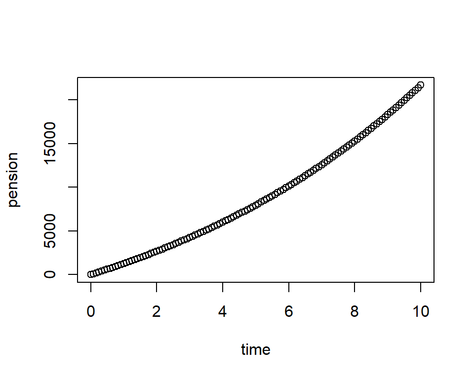

```r
# pension이 성장하는 모양양
plot(time, pension)
```

#### Example : redimensioning

Program 1과 2는 같은 결과를 내지만, 1이 더 빠르다.

```r
#Program1

n <- 1000000
x <- rep(0, n)
for (i in 1:n) x[i] <- i
```

```r
#Program2

n <- 1000000
x <- 1
for (i in 2:n) x[i] <- i
```

Program1은 전체 벡터를 한 번에 할당(preallocation)하여 메모리 관리를 더 효율적으로 수행한다.

반면, Program2는 각 반복마다 벡터 크기를 늘리기 때문에 메모리 할당이 비효율적일 수 있다.

#### Exercise

`Sys.time()`을 이용하여 위 두 프로그램의 속도를 비교해 보자.

#### break

`for` 문에서 `break`를 사용하여 특정 조건이 충족되면 반복을 중단할 수 있다.

다음 코드에서는 `y`라는 벡터의 일부 원소들을 합하여 합계가 200을 넘어가는 경우가 있는지 찾는다.

```r
y <- c(90, 30, -50, -20, -70, 80, 50, -90)
tol <- 200

sorted_descending <- sort(y, decreasing = TRUE)

partial_sum <- 0

for (i in seq_along(sorted_descending)){

  partial_sum <- partial_sum + sorted_descending[i]

  if (partial_sum > tol) {

    cat("The sum of the following elements in y is greater than", tol, ":\n")
    print(sorted_descending[1:i])

    break

  }

}
```

```
## The sum of the following elements in y is greater than 200 :
## [1] 90 80 50
```

### Looping with while

R의 `while` 문은 조건이 참인 동안 반복적으로 코드를 실행하는 루프 구조이다.  
`while` 문은 반복 횟수가 명확하지 않을 때, 특정 조건이 만족될 때까지 계속 반복해야 할 때 유용하다.

```r
# 아래 코드는 실제 유효한 코드가 아니므로 실행되지 않음
while (logical_expression) {

  expression_1
  ...

}
```

- `logical_expression`이 먼저 계산된다.
- 이 값이 `TRUE`면, 중괄호 `{ }` 안의 코드가 실행된다.
- 그런 다음 루프의 시작으로 다시 돌아간다.
  - `logical_expression`이 `FALSE`면, 루프는 멈춘다.
- `for` 반복문과 `while` 반복문은 서로 변환하여 표현할 수 있다.

#### Example : Fibonacci numbers

피보나치 수열은 각 숫자가 앞의 두 숫자의 합으로 이루어진 일련의 숫자들이다.

이 수열은 보통 0과 1이나, 1과 1로 시작한다.

```r
rm(list=ls())
Fib <- c(1, 1)
n <- 2
while (Fib[n] <= 100) {
  n <- n +1
  Fib[n] <- Fib[n-1] + Fib[n-2]
}
cat("The first Fibonacci number > 100 is Fib(", n, ") =", Fib[n], "\n")
```

```
## The first Fibonacci number > 100 is Fib( 12 ) = 144
```

#### Example : compound interest rate

아래 R 코드는 대출 상환 시나리오를 작성하여, 대출이 모두 상환되는 데에 걸리는 시간을 계산한다.

```r
r <- 0.11                # Annual rate
period <- 1/12           # Time between repayments (in years)
debt_initial <- 1000     # Amount borrowed
repayments <- 12         # Amount repaid each period

# Calculations
time <- 0
debt <- debt_initial
while (debt > 0) {
  time <- time + period
  debt <- debt*(1 + r*period) - repayments
}

# Output
cat('Loan will be repaid in', time, 'years\n')
```

```
## Loan will be repaid in 13.25 years
```

### Vector-based programming

R에서는 벡터 연산을 사용하는 것이 훨씬 효율적이다.

먼저 loop문을 통해 처음 n개의 제곱수를 합산하는 과정이다.

```r
n <- 100; S <- 0
for (i in 1:n)  S <- S + i^2
print(S)
```

```
## [1] 338350
```

벡터 기반 연산으로 한다면 훨씬 간단하다.

```r
sum((1:n)^2)
```

```
## [1] 338350
```

#### Exercise

위에서 공부한 loop 문들을 벡터 기반 프로그래밍으로 효율적으로 바꿀 수 있는지 체크해 보라.

### ifelse

`ifelse` 함수는 벡터에 대한 요소별 조건 평가를 수행한다.

아래 설며에서 `ifelse`는 `test`와 동일한 형태를 가진 값을 반환하며, 이는 `test`의 각 요소가 `TRUE`인지 `FALSE`인지에 따라 `yes` 또는 `no`에서 선택된 요소들로 채워진다.

`ifelse(test, yes = A, no = B)`

- `test`: 논리 표현식
- 반환되는 벡터는 다음으로 구성된다:
  - `A`: `test`의 요소가 `TRUE`일 때 선택되는 값
  - `B`: `test`의 요소가 `FALSE`일 때 선택되는 값

`ifelse` 함수를 사용하면 벡터의 각 요소에 대해 조건에 따라 다른 값을 손쉽게 할당할 수 있다.

```r
x <- c(-2, -1, 1, 2, -5)
ifelse( x > 0, "Positive", "Negative")
```

```
## [1] "Negative" "Negative" "Positive" "Positive" "Negative"
```

### pmin and pmax

벡터화된 버전의 최소값과 최대값

`pmax`와 `pmin`은 하나 이상의 벡터를 인수로 받아, 공통 길이로 재활용한 후 각 인수 벡터의 병렬 최대값(또는 최소값)을 제공하는 단일 벡터를 반환한다.

```r
pmin( c(1, -1, 3),
      c(3, 2, 9),
      c(2, 2, 2))
```

```
## [1]  1 -1  2
```

```r
pmax( c(1, -1, 3),
      c(3, 2, 9),
      c(2, 2, 2))
```

```
## [1] 3 2 9
```

### Program flow

다음 코드를 보고 프로그램이 어떻게 흘러갈지 생각해 보라.

```r
x <- 3
for (i in 1:3) {
  show(x)
  if (x %% 2 == 0) {
    x <- x/2
  } else {
    x <- 3*x + 1
  }
}
```

```
## [1] 3
## [1] 10
## [1] 5
```

```r
show(x)
```

```
## [1] 16
```

### Basic debugging : correcting errors

- 오류나 버그를 찾으려면 변수의 변화를 확인해야 한다.
- `cat("var=", var, "\n")`와 같은 문장을 포함시켜 변수의 값을 출력하라.
- 드라이 런(dry run): 정답을 알고 있는 간단한 시작 조건을 사용하라.
- 최종 프로그램의 짧고 간단한 버전을 사용하라.
- 그래프와 요약 통계를 활용하라.
- 들여쓰기를 신중하게 사용하라.

이러한 방법들은 코드 디버깅과 이해를 돕기 위한 유용한 전략이다.

변수의 변화를 출력하여 문제를 추적하고, 간단한 예시를 통해 프로그램을 테스트하며, 가독성을 높이기 위해 코드의 구조를 명확히 하는 것이 중요하다.

#### Example

```r
x <- 3
for (i in 1:3) {

  show(x)
  cat("i = ", i, "\n")

  if (x %% 2 == 0) {
    x <- x/2
  } else {
    x <- 3*x + 1
  }
}
```

```
## [1] 3
## i =  1
## [1] 10
## i =  2
## [1] 5
## i =  3
```

```r
show(x)
```

```
## [1] 16
```

### Good programming habits

- 좋은 프로그래밍은 영리함보다는 명확함을 추구해야 한다.
  - 실제로 코드 작성보다 코드 수정 및 오류 수정에 훨씬 더 많은 시간이 소요된다.
- 주석을 작성하라.
- 변수 이름은 설명적이어야 한다.
- 예약된 함수 이름 사용을 피하라.
  - 예를 들어, `t`, `c`, `q`는 모두 R에서 함수 이름이다.
  - `exists()` 함수를 사용하여 확인하라.
- 섹션을 구분하기 위해 빈 줄을 사용하라.

이러한 지침들은 코드의 가독성과 유지보수성을 높이는 데 도움이 된다. 명확한 코드와 주석은 다른 사람이 코드를 이해하고 수정하는 데 큰 이점을 제공한다.